# tmp1s6n16yz

## 思想剧场：艺术节的“非主流”挑战

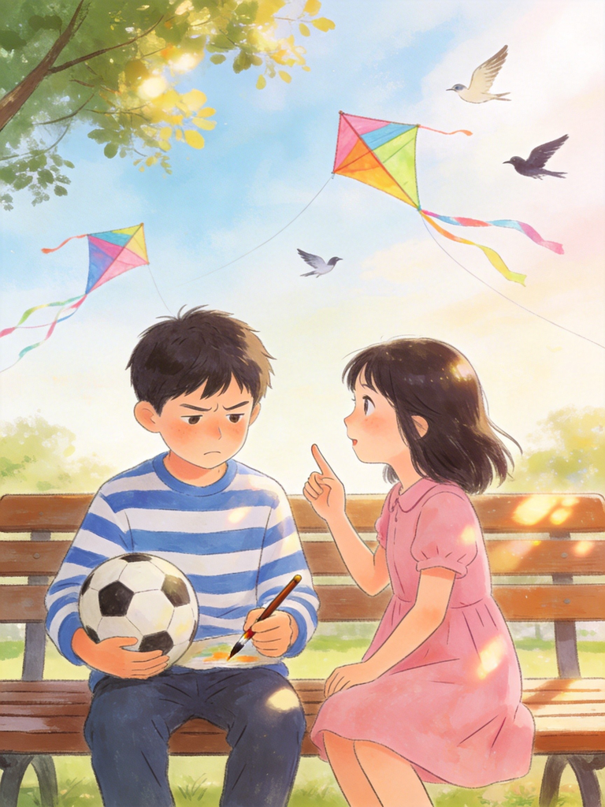

## 第一站：嵇康的“声无哀乐论”——情绪是你自己的选择

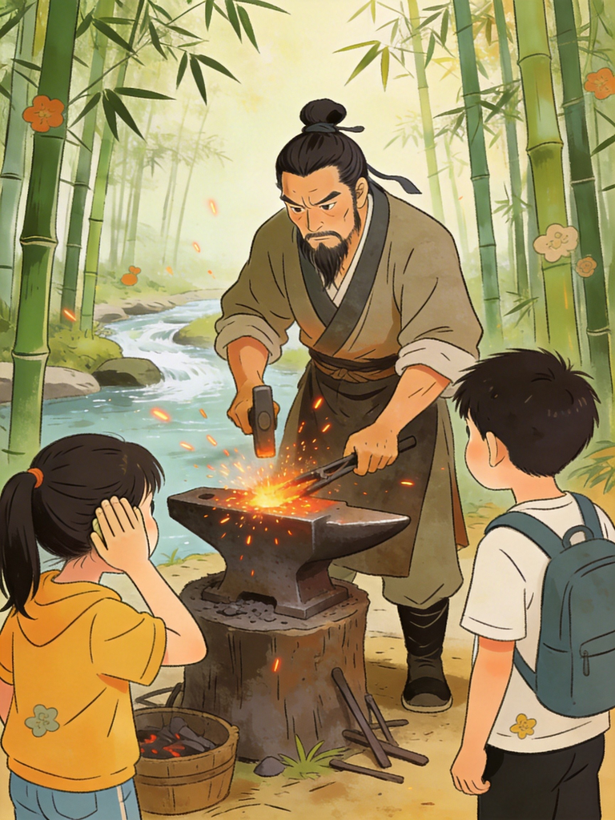

## 第二站：阮籍的“穷途之哭”——当自由遇上“此路不通”

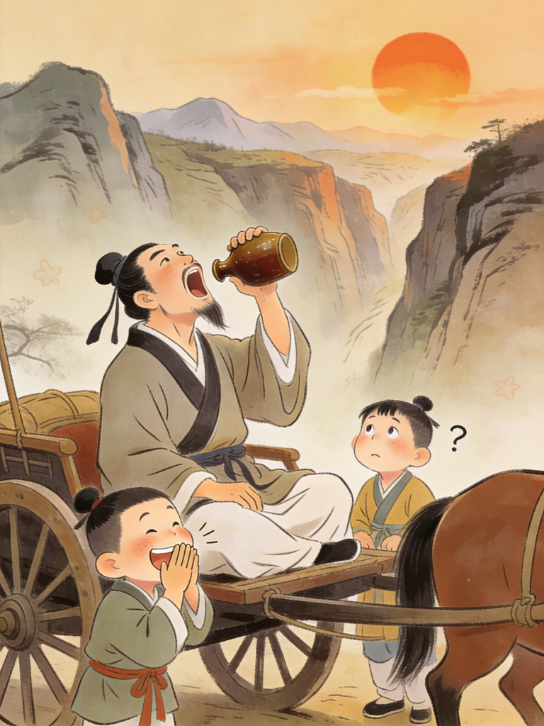

## 第三站：王弼的“得意忘言”——文字是船，意思是岸

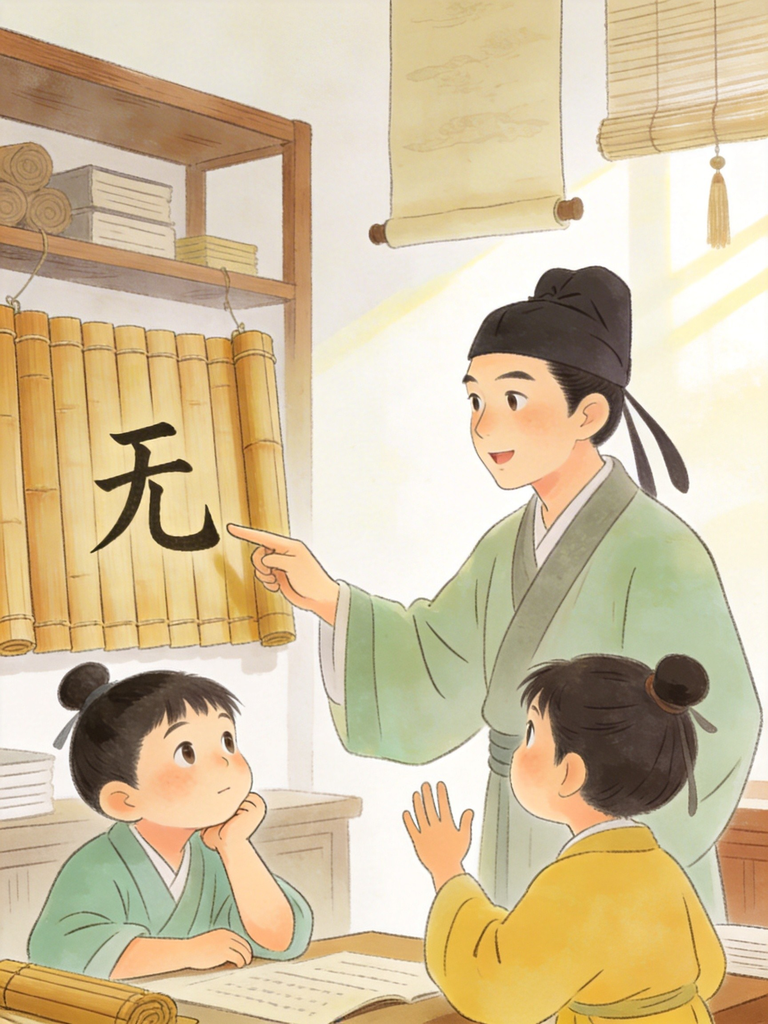

# 第七章 为什么他们那么爱自由？

**时间**：周五下午，学校艺术节筹备周  
**地点**：五年级（3）班教室  
**人物**：小美（文艺委员，爱设计）、小强（喜欢规则，有点胆小）、小智（爱思考，常问“为什么”）、小慧（感性，喜欢音乐和诗歌） （幕起） 教室黑板上画满了艺术节的海报草图。小美正兴奋地挥舞着彩笔。

**小美**：（眼睛发亮）我查资料时发现，魏晋时期有“竹林七贤”，他们超酷的！不梳头、喝酒、在竹林里弹琴唱歌，甚至……听说还有人裸奔！我们要不要在艺术节节目里也加点这种“自由精神”？

**小强**：（惊慌地摆手）不行不行！裸奔会被老师骂死的！而且……多尴尬啊！

**小智**：（托着下巴思考）他们为什么要那样做？只是为了看起来酷吗？还是有什么更深的原因？

**嵇康**：（放下铁锤，擦擦汗）裸奔？那只是最表面的自由。真正的自由，是

**你做什么，社会都不理解你，而你依然自得其乐**。 **小强**：（小声问）那……不打铁不行吗？打铁多累啊。

**嵇康**：（笑）打铁是我的选择，不是被迫。

**选择的权利**，才是自由的核心。 **阮籍**：（叹气）有选择，也得有路可走啊……我当年驾车想随意游荡，可每条路都被封了。（眼圈发红）

**小慧**：（关心地）所以您就哭了？这就是“穷途之哭”吗？

**王弼**：（翻着手中的《老子》）路封了，心还可以飞。文字困不住意思，就像笼子困不住风。

**小智**：（举手）我有个问题！如果社会不认可，自由还有意义吗？ （三人相视一笑，光影渐淡，只留下箫声余韵。） — ### 🌟 核心概念：声无哀乐论  
（来自《哲学儿童词典》补充词条） - **哲人术语**：声无哀乐论  
- **儿童比喻**：**情绪的遥控器在自己手里**。音乐只是电视机，悲喜是你自己按的频道按钮。  
- **生活案例**：考试考砸了，听任何欢快的歌都觉得像嘲讽；比赛赢了，连下雨声都像鼓掌。变的不是音乐，是你的心情。  
- **一句话记住**：情绪不在外界声音里，而在你心里。 ### 思想剧场升级版：打铁铺里的音乐辩论

**场景**：嵇康的锻铁铺，炉火正旺，锤声叮当。嵇康一边打铁，一边用口哨吹着即兴的旋律。

**小强**：（捂住耳朵）嵇康大哥，您打铁已经够吵了，还吹口哨！这能算音乐吗？

**嵇康**：（停下锤子）你觉得“吵”，我觉得“节奏”。声音只是空气振动，哪来的“吵”或“悦耳”？是你心里贴的标签。

**小慧**：（不服气）可是《二泉映月》明明就很悲伤！我每次听都想哭。

**嵇康**：如果我告诉你，这首曲子是盲艺人阿炳在街头讨生活时创作的，你是为旋律哭，还是为他的故事哭？

**小智**：（恍然大悟）哦！

**故事和记忆给声音加了“滤镜”**！就像我妈说某首歌是“初恋之歌”，我听就觉得浪漫，其实旋律很普通。 **嵇康**：对。所以别让别人的“标准答案”绑架你的耳朵。你喜欢摇滚，他喜欢古筝，没有谁“更高级”——只要是你真心喜欢的，就是你的自由。

**小强**：（犹豫）可是……如果全班同学都说某首歌土，我喜欢它会不会被嘲笑？

**小智**：（点头）就像我们班选艺术节节目，大家都想跳舞，我想演小品。但怕被说“不合群”，最后也选了跳舞。

**嵇康**：（严肃）

**自由的第一个敌人，不是别人，是你害怕被嘲笑的勇气**。敢不敢坚持“我觉得好听”，哪怕只有你一个人？敢不敢下次选你真正想演的节目？ （小强低头思考，小美在笔记本上记下“勇气=自由的第一步”。） —

### 古人这么做：《声无哀乐论》原文体验 > “心之与声，明为二物。二物者，又俗谓之有情。” **翻译**：心和声音，明明是两样东西。可世俗的人硬说它们有感情联系。

**注音**：xīn zhī yǔ shēng，míng wèi èr wù。èr wù zhě，yòu sú wèi zhī yǒu qíng。

**小美**：所以嵇康是在说，音乐本身没有情绪，情绪是我们自己“加戏”？

**嵇康**：正是。音乐像一面镜子，照出的是听者的心境。你悲伤，听什么都像哀乐；你快乐，哀乐也能听出力量。

**应用到今天**： - 当有人说“你这品味太怪”，可以回答：“我的遥控器，我做主。” - 做作业时听音乐，如果发现效率低，不是音乐不对，可能是你心里在抗拒作业。 - 创作属于自己的“心情歌单”——不同情绪时，主动选择匹配的音乐，而不是被算法推荐牵着走。 — ### 嵇康的人生剧本：不合作的代价与尊严 嵇康（224-263），“竹林七贤”的精神领袖，他的人生关键词：

**选择**。 **他会什么**： - 打铁（实实在在的体力活，不是表演） - 音乐（《广陵散》成为千古绝响） - 喝酒（但不在公共场合发酒疯） -

**拒绝做官**（多次推辞朝廷征召） **名场面：钟会来访** 权臣钟会带着厚礼来拜访嵇康，想拉拢这位名士。嵇康正在打铁，头也不抬，继续抡锤。 钟会尴尬地站了半天，转身要走。 嵇康忽然开口：“何所闻而来？何所见而去？”（你听到什么风声而来？又看到什么景象要走？） 钟会答：“闻所闻而来，见所见而去。”（听到该听的而来，看到该看的就走。） **潜台词**：你懂我为什么不来，我也懂你为何而来。但我们谁也不说破。

**结局**：因为这次“不合作”，加上为朋友辩护，嵇康被司马氏政权判处死刑。

**临刑前**：三千太学生集体请愿赦免他，嵇康却淡然一笑，索琴弹奏《广陵散》，叹道：“此曲自此绝矣。”

**小智**：（声音哽咽）他……他不怕死吗？

**嵇康**：（光影浮现）怕。但比死更可怕的，是

**活成自己讨厌的样子**。打铁是我的选择，拒官是我的选择，赴死也是我的选择——只要每一步都是我自己选的，就是自由。 **小强**：（小声）我懂了……自由不是“想做什么就做什么”，而是

**有权利选择，并承担选择的后果**。 — ### 想一想（儿童参与感统计：提问1次，立场选择1次）

1. **提问环节**：你有没有过“众人皆醉我独醒”的时刻？当时你坚持了什么，为什么？（鼓励写下或说出）

2. **立场选择**：如果全班同学都嘲笑你喜欢的音乐“土”，你会：
   - A. 偷偷喜欢，但不再公开听
   - B. 继续公开喜欢，并尝试分享为什么好听
   - C. 放弃喜欢，跟着大家听“潮”的音乐

   （选好后，在实践记录表写下理由）

## **质疑反驳**：嵇康说“情绪在你自己心里”，但如果音乐真的能让人放松或兴奋（比如运动会的进行曲），这不算音乐的力量吗？试着反驳嵇康的观点。

### 🌟 核心概念：穷途之哭

（新增术语）

- **哲人术语**：穷途之哭
- **儿童比喻**：**开车到地图边缘的眼泪**。不是车坏了，而是导航显示“前方无路”，你只能掉头，但心里不甘。
- **生活案例**：你想参加绘画比赛，但老师说“只收素描，不收水彩”——你的特长被规则堵住，那种憋屈想哭的感觉。
- **一句话记住**：穷途之哭是理想被现实卡住时的情感宣泄。 ### 思想剧场升级版：迷路司机的眼泪

  **场景**：竹林酒席，阮籍（210-263）喝得微醺，对着地图发呆。

  **阮籍**：（指着地图）我想去东海看日出，路封了；想去西山访隐士，桥断了。这马车，就像关在笼子里的鸟……

  **小慧**：（轻声）所以您不是迷路，是“无路可走”才哭的？

  **阮籍**：（点头）哭的不是迷路，是

  **自由被一寸寸压缩**。你想做点事，可每个方向都立着“禁止通行”的牌子。 **小强**：那……不能绕道吗？

  **阮籍**：绕道需要妥协。比如你想写诗批评时政，但发表必须删掉敏感词——删了，诗就不是你的诗了。

  **小智**：我有个问题！如果所有路都封了，自由是不是就死了？

  **阮籍**：（擦擦眼泪）不。

  **外在的路封了，内心的路还可以开**。所以我写诗、喝酒、弹琴——在精神世界里，我还是自己的司机。 **小美**：（记录）所以阮籍的自由是“内心自由”，哪怕外部环境不友好？

  **嵇康**：（插话）他比我聪明。我硬碰硬，死了；他“哭”着绕弯，活着，还把诗留了下来。 —

  ### 阮籍的诗与酒：逃避还是抵抗？ 阮籍的著名行为：**驾车至路尽头，痛哭而返**。 **为什么是“哭”而不是“怒”**：
- 怒是反抗，哭是无奈
- 哭是情感的真实流露，不掩饰脆弱
- 在魏晋那个“谈玄论道”的时代，哭成了一种沉默的抗议 **他的《咏怀诗》选段**： > 夜中不能寐，起坐弹鸣琴。  
  > 薄帷鉴明月，清风吹我襟。  
  > 孤鸿号外野，翔鸟鸣北林。  
  > 徘徊将何见？忧思独伤心。 **注音**：yè zhōng bù néng mèi，qǐ zuò tán míng qín。  
  bó wéi jiàn míng yuè，qīng fēng chuī wǒ jīn。  
  gū hóng háo wài yě，xiáng niǎo míng běi lín。  
  pái huái jiāng hé jiàn？yōu sī dú shāng xīn。 **小慧**：（轻声朗读）感觉好孤独……但也好美。

**阮籍**：孤独是因为无人理解，美是因为真实。

**真实的情绪，本身就是一种自由**。 **对比嵇康与阮籍**： | | 嵇康 | 阮籍 | |———-|——————–|——————–| | 抵抗方式 | 正面刚，不妥协 | 迂回哭，不合作 | | 代价 | 生命 | 内心煎熬 | | 留给后世 | 《广陵散》的传说 | 82首《咏怀诗》 | | 共同点 |

**绝不背叛自己的内心** | | — ### 实践的边界：你的自由半径有多大？ **讨论题**：真正的自由，是

**外部空间大**，还是**内心不妥协**？ **三种自由模式**：

1. **学生的自由**：可以选兴趣班，但必须参加高考→自由有限但现实
2. **艺术家的自由**：可以随意创作，但可能没钱吃饭→自由全面但生存难
3. **隐士的自由**：远离社会，自给自足→自由纯粹但无影响力

**阮籍的难题**： > 如果你的自由

**只让你自己舒服**，却对世界毫无改变，这样的自由是不是有点自私？ **小智**：那……有没有“既自由又有用”的办法？

**阮籍**：有。我的诗虽然没直接反抗，但让后人看到了那个时代的压抑——

**记录真实，本身就是一种力量**。 **应用到今天**：

- 写日记记录你的“不自由时刻”
- 用绘画表达说不出口的情绪

## 和信任的人分享你的“穷途之哭”

1. **提问环节**：你遇到过“此路不通”的情况吗？当时是怎么处理的？如果重来一次，你会尝试阮籍的“迂回”方式吗？
2. **质疑反驳**：有人说阮籍“只会哭，不行动”，是懦弱的表现。你同意吗？试着为阮籍辩护。
3. **立场选择**：面对一个明显不公的班级规则，你会：
   - A. 直接找老师抗议（嵇康式）
   - B. 写匿名信或通过作文表达（阮籍式）
   - C. 默默忍受，等毕业再说

## （在实践记录表写下选择理由）

### 🌟 核心概念：得意忘言

（新增术语）

- **哲人术语**：得意忘言
- **儿童比喻**：**文字是渡河的小船**。过了河，就该上岸，而不是背着船继续走。
- **生活案例**：老师讲解数学公式，你终于懂了“哦，原来是这个意思！”——这时，公式本身（文字）就不重要了，重要的是你掌握的方法。
- **一句话记住**：理解意思后，要敢于放下文字，用自己的话重新表达。 ### 🌟 核心概念：贵无论  
  （新增术语）
- **哲人术语**：贵无论
- **儿童比喻**：**空房间的价值**。房间贵的是“空”，能放家具、能住人；如果塞满垃圾，反而没价值。
- **生活案例**：周末没有安排（“空”），你可以选择看书、打球、发呆——这份“可能性”比被补习班填满的周末更珍贵。
- **一句话记住**：最宝贵的是“无”——可能性、空间、潜力。 ### 思想剧场升级版：读不懂的《老子》与少年天才

  **场景**：竹林石桌旁，王弼（226-249）正在翻一本泛黄的《老子》。小智凑过去看，眉头紧锁。

  **小智**：这写的什么啊！“道可道，非常道”……每个字都认识，连起来完全不懂！

  **王弼**：（合上书笑）你们被

  **文字**困住了。老子的意思是“无为”，你们却在纠结“无”字怎么写，“为”字怎么解。 **小强**：那怎么才能懂？

  **王弼**：我教你们“三步阅读法”：
1. **读文字**（看原文）
2. **抓意思**（想象作者想说什么）
3. **忘文字**（用自己的话复述） **小美**：可是……万一理解错了呢？

   **王弼**：**理解没有标准答案，只有深浅之别**。就像看云——你说像龙，他说像马，都对，因为云本来就在变化。 **小慧**：那“贵无论”又是什么？

   **王弼**：你们觉得杯子贵的是什么？
- **小强**：陶瓷质量？
- **小智**：花纹设计？
- **王弼**：都错。杯子贵的是

  **空**——能装水。如果没有“空”，它就是实心陶块，一文不值。 **应用到自由**： > 真正的自由，是

  **有“无”的空间**——不是必须做什么，而是有选择的可能性。 **小智**：（兴奋）我懂了！自由不是“我想做什么就做什么”，而是

  **我能选择做或不做，而且有很多选项**！ **王弼**：聪明。所以别让“必须”填满你的生活，留点“空”，自由才会住进来。 —

  ### 古人这么说：《周易略例》金句 > “得意在忘言，忘象在得意。” **翻译**：要抓住意思，就必须忘掉文字；要忘掉符号，就必须先抓住意思。

  **注音**：dé yì zài wàng yán，wàng xiàng zài dé yì。

  **小强**：这不矛盾吗？既要“忘”又要“得”？

  **王弼**：不矛盾。比如学自行车：
1. 看说明书（文字）
2. 理解“平衡”是核心（得意）
3. 骑上车，忘记说明书，专注于身体感觉（忘言） **应用到今天的学习**：
- 背课文时，先理解作者想表达的情感
- 学公式时，想明白它解决什么问题

## 读哲学时，别被术语吓住，找背后的生活智慧

### 王弼的“可能性哲学”：23岁天才的早逝与永恒

- 王弼的人生关键词：**可能性**。 **他有多天才**：
- 10岁熟读《老子》《庄子》
- 18岁注解《周易》，震惊学界
- 23岁病逝，留下《老子注》《周易注》成为经典 **他的核心思想**：
- **得意忘言**：理解比记忆重要
- **贵无论**：“无”比“有”更根本
- **以无为本**：万物从“无”中产生，依赖“无”存在

  **比喻理解**：
- 电影屏幕是“无”，影像才是“有”——没有空白屏幕，影像无处呈现
- 假期计划表里的“空白时段”最珍贵，因为可以随意安排 **王弼的自由观**： > 自由不是拥有更多，而是不被已有的一切束缚。清空偏见，才能装进新思想。

  **小智**：他23岁就去世了……好可惜。

## （在实践记录表写下理由，并观察哪种方式让你更放松、更有创造力）

## 古人故事集：魏晋名士的趣闻轶事

### 嵇康的“绝交信”——朋友归朋友，原则归原则

   嵇康有个好朋友叫山涛，后来山涛做了大官，想推荐嵇康也来做官。嵇康不但拒绝，还写了一封著名的《与山巨源绝交书》。 **儿童版翻译**： “山涛兄，谢谢你想着我。但咱俩就像猫和狗——你爱逛皇宫，我爱钻竹林。你非拉我去皇宫，我会憋死；我非拉你来竹林，你会无聊死。不如各玩各的，还是朋友，但别互相改造。”

   **小智问**：这不是伤朋友感情吗？

   **嵇康答**：真正的朋友，是允许对方做自己。如果因为选择不同就绝交，那也不是真朋友。

   **应用到今天**：
- 好朋友想让你一起报某个兴趣班，你真心不喜欢，可以温和拒绝：“我更想学画画，但周末我们可以一起打球。”
- **自由包括说“不”的权利**，即使是对好朋友。 ### 阮籍的“青白眼”——喜欢就青眼，讨厌就白眼 阮籍有个特异功能：眼睛会变色。看到喜欢的人，眼珠是黑色的（青眼）；看到讨厌的虚伪之人，眼珠翻上去只剩眼白（白眼）。 **名场面**： 嵇康的哥哥嵇喜来吊丧，阮籍觉得他太官腔，翻白眼；嵇康带着酒琴来，阮籍大喜，青眼相待。

  **小慧问**：这不是很没礼貌吗？

  **阮籍答**：礼貌是表面的，真实是内心的。我宁愿真实地翻白眼，也不虚伪地假笑。

  **应用到今天**：
- 不必强迫自己对所有人都“热情友好”
- 但可以用更温和的方式表达好恶，比如：“我现在想自己呆会儿” ### 王弼的“少年天才”——23岁写完千古注解 王弼10岁就能和老学者辩论《老子》，对方常被问倒。18岁注解《周易》，震惊学界。23岁病逝前，已完成《老子注》《周易注》，成为后世研究必备经典。 **小强问**：这么聪明，为什么不多活几年？

  **王弼答**：思想的寿命不在于身体长短。我的注解让千万人理解老庄，这比活到100岁更有意义。

  **应用到今天**：
- 年龄不是限制，小学生也可以有深刻思考

## 专注做好一件事，可能影响远超想象

## 知识迷宫：自由选择的岔路口

- **迷宫规则**： 你来到一个三岔路口，每条路代表一种自由选择。每条路上有挑战和奖励，选一条走到底，看看你会遇到什么。 ### 路口一：嵇康的“勇气之路”
- **挑战**：全班同学都在玩某款游戏，你觉得无聊，但怕被孤立。
- **选择**： A. 假装喜欢，加入他们（安全但违心） B. 坚持不玩，自己看书（孤独但真实） C. 提议玩另一个游戏（冒险但可能双赢）
- **走到底**： 选A→获得“合群勋章”，但晚上失眠，觉得自己像假人。 选B→获得“真实徽章”，第三天发现有两个同学悄悄对你说“其实我也不喜欢那游戏”。 选C→获得“创意奖杯”，一半同学跟你玩新游戏，一半继续旧游戏——你成了桥梁。 ### 路口二：阮籍的“情感之路”
- **挑战**：被老师冤枉批评，你很委屈。
- **选择**： A. 忍气吞声，回家哭（压抑） B. 当场大哭反驳（情绪爆发） C. 课后找老师平静说明（理性表达）
- **走到底**： 选A→获得“忍耐之星”，但连续三天做噩梦。 选B→获得“真实之泪”，老师道歉，但同学觉得你“太情绪化”。 选C→获得“沟通勋章”，老师不仅道歉，还在全班表扬你的冷静。 ### 路口三：王弼的“可能性之路”
- **挑战**：周末下午突然空出来了，完全没计划。
- **选择**： A. 赶紧报个临时班填满（害怕空白） B. 躺在床上刷手机（被动填满） C. 拿出纸笔列“我想尝试的10件小事”，选一件做（主动创造）
- **走到底**： 选A→获得“充实证书”，但累且没新收获。 选B→获得“放松贴纸”，但晚上觉得空虚。 选C→获得“探索地图”，你尝试了做手工，虽然失败但灵感迸发。

  **迷宫出口**： 无论选哪条路，你都会拿到一张“自由探险家”证书，上面写着： > 自由不是选对路，而是

  **知道自己在选择**。 — ## 心理实验：音乐真的没有情绪吗？ 嵇康说“声无哀乐”，但现代心理学发现，音乐确实能影响情绪。让我们设计一个家庭小实验，验证谁的观点更接近真相。 ### 实验设计 **假设**：同样的音乐，在不同心境下会被感知为不同情绪。

  **材料**：手机/音乐播放器、纸笔、计时器

  **参与者**：你 + 至少一位家人/朋友 ### 实验步骤
1. **选曲**：选一首纯音乐（无歌词），如钢琴曲《River Flows in You》或古琴曲《流水》。
2. **情境创设**：
   - A组：先做5分钟快乐的事（讲笑话、看搞笑视频）
   - B组：先回忆一件难过的事（写下来）
   - C组：保持平静（静坐3分钟）
3. **听音乐**：所有人同时听同一首曲子，计时3分钟。
4. **记录感受**：听完后立即写下：
   - 情绪评分（1-10分，1=非常悲伤，10=非常快乐）
   - 联想到的画面或记忆
   - 身体感受（如“心跳变慢”“想跳舞”） ### 数据分析 对比三组的情绪评分：
- 如果A组评分显著高于B组 → 支持“心境影响感知”（嵇康观点）
- 如果三组评分接近 → 音乐本身有固定情绪倾向
- 如果所有人都觉得“快乐”或“悲伤” → 音乐有普遍情绪色彩 ### 实验变式
- **文化背景**：让中国朋友和外国朋友听同一首中国古琴曲，看联想差异
- **年龄差异**：对比孩子和父母的感受
- **盲听测试**：不告诉曲目标题，避免标题暗示 ### 结论讨论
- 嵇康的“声无哀乐论”在今天还成立吗？
- 音乐的情绪是“客观存在”还是“主观建构”？

## 这个实验如何帮助你理解“自由”——是音乐束缚了你的情绪，还是你选择了情绪？

## 漫画脚本：思想剧场视觉化

- **场景**：教室黑板前，嵇康、阮籍、王弼以半透明光影出现，四个孩子围坐。

  **分镜1**（全景）
- 教室窗户透进夕阳余晖
- 黑板上画着艺术节海报草图
- 小美挥舞彩笔，小强捂耳朵，小智托腮，小慧哼歌
- 文字泡：“竹林七贤裸奔？我们要不要也加点自由精神？” **分镜2**（特写：箫声引入）
- 窗外竹影摇曳，箫声音符具象化飘入
- 嵇康半透明身影浮现，赤膊打铁，汗珠晶莹
- 文字泡：“裸奔？那只是最表面的自由。” **分镜3**（对话分格）
- 嵇康锻铁铺：炉火、铁砧、锤子
- 小强捂耳朵：“太吵了！这算音乐吗？”
- 嵇康停锤：“声音只是空气振动，是你心里贴的标签。”
- 小慧不服气：“《二泉映月》明明很悲伤！”
- 嵇康：“如果我告诉你创作背景，你是为旋律哭，还是为故事哭？” **分镜4**（蒙太奇：情绪滤镜）
- 同一段音乐波纹，在不同心境下变色：
  - 开心时→金色波纹，联想生日派对
  - 难过时→蓝色波纹，联想雨天离别
  - 平静时→绿色波纹，联想森林漫步
- 字幕：“情绪不在音乐里，而在你心里。” **分镜5**（阮籍驾车）
- 马车驶向路尽头，“禁止通行”路牌特写
- 阮籍仰头大哭，眼泪夸张化飞溅
- 文字泡：“无路可走……自由被一寸寸压缩。” **分镜6**（王弼读书）
- 王弼翻《老子》，文字从书中飞出变成小船
- 小智困惑脸，头顶问号：“每个字都认识，连起来不懂！”
- 王弼笑，手指一点，文字小船载着“意思”渡河
- 对岸：“用自己的话复述” **分镜7**（合成：自由三部曲）
- 三格并列：
  - 嵇康举锤：“选择的勇气”
  - 阮籍拭泪：“情感的真实”
  - 王弼指空白：“可能性的空间”

## 底部大字：“自由不是一种状态，而是一种生活方式。”

## 实践环节：三周“自由实验”计划

### 实验设计理念

  **我的自由实验记录表** 姓名：__________  
  开始日期：__________  
  实验周次：第一周 / 第二周 / 第三周（圈选） | 日期 | 任务完成（✓） | 关键感受（1-2句话） | 自由指数（1-5星） | |——|—————-|———————-|——————-| | 周一 | | | | | 周二 | | | | | … | | | | | 周日 | | | | **本周最大收获**：__________________________________________________

  **下周想改进**：____________________________________________________ ### 预期产出样例

  **小明（10岁）的第一周记录片段**：
- 周一：我选了重金属音乐当晚餐背景，爸爸皱眉说“太吵”，但我坚持说“我喜欢节奏感”。最后全家听了半首，妈妈笑着说“至少很提神”。⭐️⭐️⭐️⭐️
- 周三：分析了漫威角色“死侍”，他嘴炮不断、不按常理出牌，但内心有自己坚守的正义。自由代价：被所有人当成疯子。⭐️⭐️⭐️⭐️⭐️

## 周日总结：坚持自我最难的是“怕被孤立”。但当我分享为什么喜欢重金属时，同桌居然说“我也试试看”。原来真实能吸引同类。

## 智慧探险地图碎片 #7

```
┌──────────────────────────────────────────────┐
│  问题：为什么他们那么爱自由？                │
├──────────────────────────────────────────────┤
│  遇见智者：                                  │
│  • 嵇康——打铁也不做官的“不合作者”           │
│     （声无哀乐论：情绪遥控器在自己手里）    │
│  • 阮籍——开车到路尽头的“哭泣诗人”           │
│     （穷途之哭：理想被现实卡住的眼泪）      │
│  • 王弼——23岁注解经典的“少年天才”           │
│     （得意忘言：文字是船，意思是岸）        │
│     （贵无论：空房间比塞满的房间更珍贵）    │
├──────────────────────────────────────────────┤
│  思想工具：                                  │
│  🛠️ “自由三部曲”                            │
│     ① 行为自由（嵇康）——选择的勇气          │
│     ② 情感自由（阮籍）——真实的情绪          │
│     ③ 认知自由（王弼）——可能性的空间        │
│                                               │
│  🧭 实践指南：                               │
│     • 三周“自由实验”计划（见实践环节）       │
│     • 每日任务+记录表，亲子/独立双版本       │
├──────────────────────────────────────────────┤
│  留下你的问题：                              │
│  “如果社会不认可，我的自由还有价值吗？”      │
│  “哭是不是一种懦弱？还是另一种勇敢？”        │
│  “空白时间太多，会不会变成浪费时间？”        │
└──────────────────────────────────────────────┘
```

## 给家长的提示：如何与孩子讨论“魏晋风度”

### 讨论切入点

1. **校园场景迁移**：
   - “如果全班同学都嘲笑你的爱好，你会怎么办？”（关联嵇康）
   - “当你觉得规则不公平，除了生气，还能怎么做？”（关联阮籍）
   - “周末是计划满满好，还是留白探索好？”（关联王弼）
2. **情绪教育契机**：
   - 阮籍的“哭”不是软弱，而是情感的真实表达
   - 帮助孩子区分“健康的情绪宣泄”与“消极的抱怨”
   - 鼓励创意表达：写诗、绘画、音乐创作
3. **自由与责任的平衡**：
   - 嵇康的选择需要勇气，也要承担后果
   - 讨论“个人自由”与“集体规则”的边界
   - 实践环节中的“亲子合作版”是很好的对话载体 ### 推荐延伸资源
- **书籍**：《世说新语》儿童选编版（找有趣小故事）
- **影视**：动画电影《长安三万里》中的李白形象（类似魏晋名士的自由不羁）
- **音乐**：古琴曲《广陵散》《梅花三弄》体验中国古典音乐的自由精神
- **实地**：如有条件，参观竹林、山林，体验“自然中的自由感” ### 注意事项
- 避免美化“逃避”：魏晋名士的隐居有时代局限，不是所有问题都该逃避
- 强调“建设性自由”：自由不仅是拒绝，更是创造的可能性

## 关注孩子心理：如果孩子对“不自由”反应强烈，可能是需要更多情感支持

- **本章核心**：自由不是单一状态，而是 **选择的勇气（嵇康）、情感的真实（阮籍）、可能性的空间（王弼）** 三位一体的生活方式。通过三周实验，让孩子在具体行动中体验自由的不同维度，理解古人智慧如何照亮现代生活。 **本章字数**：约7,500字  
  **核心哲人**：嵇康（声无哀乐论、不合作）、阮籍（穷途之哭、情感自由）、王弼（得意忘言、贵无论）  
  **技能卡关联**：
- JK-01 声无哀乐论（情绪自主）
- JK-02 越名教而任自然（精神独立）
- RZ-01 穷途之哭（情感真实）
- WB-01 得意忘言（理解本质）

## WB-02 贵无论（珍视可能性）

- **下一章预告**：第八章“烦恼是怎么来的？”——慧能、神秀与禅宗的“心灵扫除术”